# Binomial(5, 0.1) population

Part of my CLT stress test. Six values, and most draws are zero.

Author

Geonho Lee

Published

October 11, 2026

```r
source("clt_helpers.R")

student_id <- 5146
cutoff <- 0.3
```

## 1 The population

One draw is the number of successes in 5 tries when each try has a 10% chance. Most of the time the answer is 0 (59% of the time), and anything above 2 is rare. The mean is np = 0.5 and the sd is sqrt(np(1 - p)) = 0.67. It is right skewed (skewness 1.19), has a slightly heavy tail (kurtosis 4.02, excess 1.02), and like the die it only takes 6 values, but here 59% of the weight sits on just one of them. Each draw is independent of the others, they all come from the same Binomial(5, 0.1), and the variance is finite (0.45), so none of the CLT assumptions is broken here.

```r
size <- 5
p <- 0.1

pop_mean <- size * p
pop_sd <- sqrt(size * p * (1 - p))
pop_skew <- (1 - 2 * p) / pop_sd
pop_exkurt <- (1 - 6 * p * (1 - p)) / (size * p * (1 - p))

round(c(pop_mean = pop_mean, pop_sd = pop_sd, pop_skew = pop_skew, pop_exkurt = pop_exkurt), 3)
```

```
  pop_mean     pop_sd   pop_skew pop_exkurt
     0.500      0.671      1.193      1.022
```

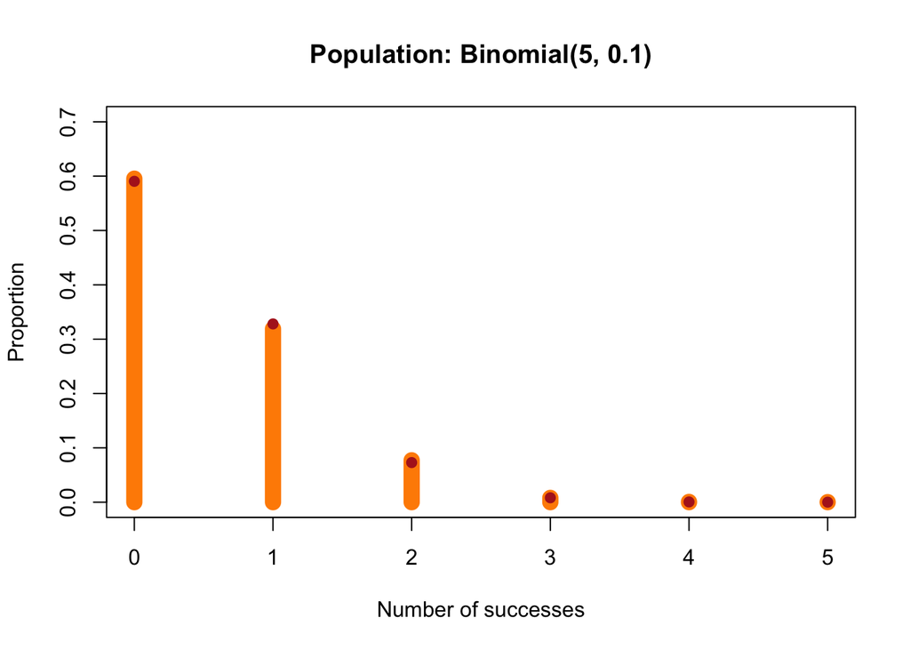

Share of each value in 10,000 draws (bars) and the exact binomial probabilities (red dots).

```r
set.seed(student_id)
population_draws <- rbinom(10000, size = size, prob = p)

values <- 0:size
observed <- as.numeric(table(factor(population_draws, levels = values))) / 10000

plot(values, observed, type = "h", lwd = 12, col = "darkorange", ylim = c(0, 0.7),
     xlab = "Number of successes", ylab = "Proportion",
     main = "Population: Binomial(5, 0.1)")
points(values, dbinom(values, size, p), pch = 19, col = "firebrick")
```

## 2 What I expected before running anything

Using the same formulas as before, skewness needs n of about 16 to get under 0.3, and kurtosis only needs about 3.4. So skewness is the limit again and I predicted n = 16. That is faster than the exponential (45) because the skewness here is 1.19 instead of 2, even though this population looks a lot messier.

```r
n_for_skew <- (pop_skew / cutoff)^2
n_for_kurt <- pop_exkurt / cutoff

c(n_for_skew = n_for_skew, n_for_kurt = n_for_kurt)
```

```
n_for_skew n_for_kurt
 15.802469   3.407407
```

## 3 Simulation

Same loop as before, and same 51 values of n as the exponential file. For each n I draw 10,000 samples of size n and keep each sample’s mean.

```r
sim <- run_simulation(
  generator = function(n) rbinom(n, size = size, prob = p),
  pop_sd = pop_sd,
  seed = student_id
)

results <- sim$results
```

## 4 What happens as n grows

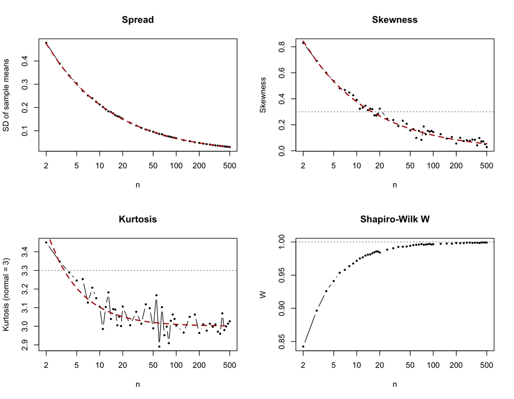

Red dashed = theory, gray dotted = my cutoff.

```r
plot_trends(results, pop_skew = pop_skew, pop_exkurt = pop_exkurt, cutoff = cutoff)
```

```r
show_rows <- results$n %in% c(2, 5, 10, 15, 16, 17, 20, 25, 30, 50, 100, 500)
knitr::kable(round(results[show_rows, ], 3), row.names = FALSE)
```

| n | mean | sd | theory_se | skewness | kurtosis | shapiro_w | sd_error |
| --- | --- | --- | --- | --- | --- | --- | --- |
| 2 | 0.502 | 0.477 | 0.474 | 0.829 | 3.450 | 0.842 | 0.006 |
| 5 | 0.499 | 0.304 | 0.300 | 0.536 | 3.246 | 0.941 | 0.013 |
| 10 | 0.502 | 0.213 | 0.212 | 0.392 | 3.105 | 0.972 | 0.003 |
| 15 | 0.500 | 0.175 | 0.173 | 0.324 | 3.092 | 0.981 | 0.008 |
| 16 | 0.502 | 0.167 | 0.168 | 0.320 | 3.090 | 0.983 | 0.006 |
| 17 | 0.501 | 0.162 | 0.163 | 0.273 | 3.005 | 0.985 | 0.003 |
| 20 | 0.500 | 0.151 | 0.150 | 0.323 | 3.106 | 0.984 | 0.005 |
| 25 | 0.499 | 0.134 | 0.134 | 0.246 | 3.006 | 0.988 | 0.004 |
| 30 | 0.499 | 0.122 | 0.122 | 0.237 | 3.077 | 0.991 | 0.004 |
| 50 | 0.501 | 0.096 | 0.095 | 0.156 | 2.989 | 0.994 | 0.007 |
| 100 | 0.500 | 0.067 | 0.067 | 0.143 | 3.004 | 0.997 | 0.005 |
| 500 | 0.500 | 0.030 | 0.030 | 0.028 | 3.027 | 0.999 | 0.007 |

```r
# checks over every n I tried, not just the rows above
c(max_mean_gap = round(max(abs(results$mean - pop_mean)), 3),
  max_sd_error = round(max(results$sd_error), 3))
```

```
max_mean_gap max_sd_error
       0.003        0.024
```

The mean always stays within 0.004 of 0.5, and the sd stays within 3% of σ/√n (worst gap 2.4%, at n = 65). Kurtosis drops under 3.3 by n = 5 and is not a problem after that. Skewness follows the red theory line down, and it is the thing that decides n. Shapiro W starts at 0.842 at n = 2, lower than the normal, die or exponential, and it is still only 0.988 at n = 25. My guess is that is because so many of the means are tied at the same few values.

## 5 A closer look

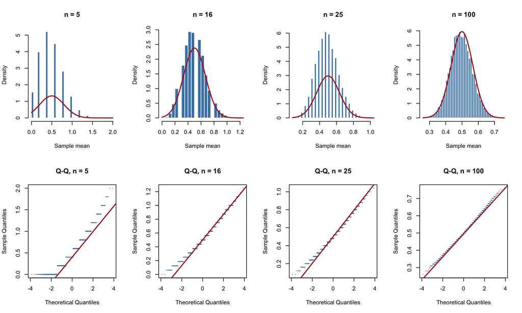

```r
chosen_n <- smallest_n(results, cutoff = cutoff)
plot_means(sim, show_n = c(5, 16, chosen_n, 100), pop_mean = pop_mean, pop_sd = pop_sd)
```

```r
# how many different values the mean takes, and how often it's exactly 0
sapply(c("2", "5", "30"), function(k) length(unique(sim$means[[k]])))
```

```
 2  5 30
 7 11 27
```

```r
sapply(c("2", "5", "10"), function(k) mean(sim$means[[k]] == 0))
```

```
     2      5     10
0.3508 0.0778 0.0039
```

At n = 5 the mean is exactly 0 in about 8% of samples (every draw was 0; the exact chance is 7.2%), and at n = 2 it is 35%. That is the long flat stretch at the bottom left of the n = 5 Q-Q plot. The top end of that plot also shoots way above the line, which is the right skew. At n = 16, where my formula said it should pass, the middle of the staircase sits on the line but the bottom end still flattens out, because the mean cannot go below 0. At n = 25 that bottom bend is smaller and the top end is on the line. The n = 5 and n = 25 histograms have the same comb look as the die file, for the same reason: the mean only lands on multiples of 1/n.

One thing confused me in the n = 100 Q-Q plot. Almost every point sits a little above the line, which made it look shifted. I checked it instead of assuming something was wrong:

```r
# qqline draws its line through the 25th and 75th percentiles, so I rebuilt that line
# and measured how far the points are from it at n = 100
m100 <- sim$means[["100"]]
qq <- qqnorm(m100, plot.it = FALSE)
slope <- diff(quantile(m100, c(0.25, 0.75))) / diff(qnorm(c(0.25, 0.75)))
intercept <- quantile(m100, 0.25) - slope * qnorm(0.25)
gap <- qq$y - (intercept + slope * qq$x)

c(share_above = round(mean(gap > 0), 3), median_gap = round(median(gap), 4), step = 1 / 100)
```

```
share_above  median_gap        step
     0.9190      0.0051      0.0100
```

About 92% of the points are above the line, but the typical gap is smaller than one step (the mean moves in steps of 1/100 here). So it is the tied values and where the line happens to pass through the steps, not the distribution being off. The staircase runs parallel to the line, which is what matters.

## 6 My decision

```r
chosen_n
```

```
[1] 25
```

Under the same rule as the other files (skewness and kurtosis within 0.3 of normal, sd within 3% of theory, and it has to keep passing for every bigger n), the smallest n I can defend is **n = 25**. That is 9 more than I predicted, so I looked at skewness right around the cutoff:

```r
around <- results[results$n %in% 14:25, c("n", "skewness")]
around$formula <- pop_skew / sqrt(around$n)
print(round(around, 3), row.names = FALSE)
```

```
  n skewness formula
 14    0.313   0.319
 15    0.324   0.308
 16    0.320   0.298
 17    0.273   0.289
 18    0.271   0.281
 19    0.285   0.274
 20    0.323   0.267
 25    0.246   0.239
```

The formula says skewness drops under 0.3 at n = 16. My simulation is still a bit over the cutoff there (0.320), then passes at 17, 18 and 19. Then n = 20 comes out at 0.323 when the formula says 0.267, and because of my keep-passing rule that one value pushes the answer to 25. That is simulation noise, like what I saw in the normal file, just landing on the wrong side of the line.

Same data, different cutoff:

```r
data.frame(
  cutoff = c(0.5, 0.3, 0.2, 0.1, 0.05),
  smallest_n = sapply(c(0.5, 0.3, 0.2, 0.1, 0.05), function(k) smallest_n(results, cutoff = k))
)
```

```
  cutoff smallest_n
1   0.50          6
2   0.30         25
3   0.20         50
4   0.10        200
5   0.05        500
```

With a 0.5 cutoff, n = 6 is enough, and at 0.2 it takes 50. So under my rule 30 is enough here, but not by much, and under the 0.2 cutoff it would not be. I do not read much into the 0.1 and 0.05 rows, since the normal file showed the noise is about that size.

## 7 Does the seed matter?

```r
sim_167 <- run_simulation(
  generator = function(n) rbinom(n, size = size, prob = p),
  pop_sd = pop_sd,
  seed = 167
)
smallest_n(sim_167$results, cutoff = cutoff)
```

```
[1] 16
```

With seed 167 the answer is 16, exactly what the formula predicted. So between the two seeds the answer is somewhere from 16 to 25, and under 30 either way.

## 8 What surprised me

The formula said this one would beat the exponential, and it did, but six values that are mostly zeros getting to normal faster than a smooth curve still looks odd. The number that mattered was skewness, and 1.19 is smaller than the exponential’s 2, so lumpy did not mean slow. The other thing was how much one noisy n moved my answer. The formula’s 16 and my 25 are both reasonable, and which one I get depends on the seed.